# Mitral valve analysis

Steve Simon

May 23, 2017

```r
mv1 <- read.csv("mitral1.csv", as.is=TRUE)
mv3 <- read.csv("mitral3.csv", as.is=TRUE)
names(mv1) %<>% tolower
names(mv3) %<>% tolower
names(mv1) %<>% gsub("\\.", "_", .)
names(mv3) %<>% gsub("\\.", "_", .)
names(mv1) %<>% gsub("_+",  "_", .)
names(mv3) %<>% gsub("_+",  "_", .)
names(mv1) %<>% gsub("_$",  "",  .)
names(mv3) %<>% gsub("_$",  "",  .)
```

MITRAL

1. Arithmetic data for columns where possible – mean, median, SD, range
2. What is the long-term survival in children who have had prosthetic MVR?
3. Relationship of survival to
- Age at 1st MVR (P-B) birthdate date_of_valve_replacement
- Weight at 1st MVR (Q) weight_at_surgery_kg
- Valve type at 1st MVR (N, but also S) mechanical_valve_used_y_n valve_make
- Valve size at 1st MVR (R) valve_size_mm
- Underlying disease (M) for_all_columns_999_unknown_888_n_a_underlying_disease_ex_cavc_etc
- Underlying hemodynamic mechanism – MR versus MS versus both (O) underlying_lesion_regurgitation_or_stenosis
- Perfusion time (T) cpb_time_minutes
- Concomitant prosthetic AVR (V) additional_valve_replaced_aortic_pulm_tri
- Initial Hospital length of stay (U-P) discharge_date MINUS date_of_valve_replacement
- Era effect - < 1990 versus 1990s and up to 2003 (P) date_of_valve_replacement
- Geography – State (F) state
- Institution (not important)
4. Causes of death – big piles only (Tab 3, D and E) cause_of_death AND cause_of_death_desc
5. Early deaths (PCCC) versus late deaths (NDI) – compare profiles (H versus BI) pccc_death AND ndi_death
6. Interactions (think about it)
7. Confounders – collinearity
8. Need competing risk plot – I need to think about what goes in this once we see some results
9. Redo stuff – we may not have time for this before abstract deadline

AORTIC

1. Arithmetic data for columns where possible – mean, median, SD, range
2. What is the long-term survival of children with AVR?
3. Head to head comparison of Ross versus Bio prosthesis versus Mechanical prosthesis looking at survival within the 3 groups and relation to following
- Age at 1st AVR
- Weight at 1st AVR
- Valve type at 1st AVR
- Valve size at 1st AVR
- Underlying disease
- Underlying hemodynamic mechanism – AR versus AS versus both
- Perfusion time
- Concomitant prosthetic MVR
- Initial Hospital length of stay
- Era effect - < 1990 versus 1990s and up to 2003
- Geography – State
- Institution
4. Causes of death – Big piles only
5. Early deaths (PCCC) versus late deaths (NDI) – compare profiles
6. Interactions
7. Confounders – collinearity
8. Kaplan Meir – Ross versus Bio versus Mechanical AVR
9. Competing risk – will think thru this some more
10. Redo stuff – we may not have time for this before abstract deadline

```r
i1 <- which(names(mv1)=="x")
i2 <- dim(mv1)[2]
for (i in i1:i2) {
  print(table(mv1[, i], useNA="always"))
}
```

```
##
## <NA>
##  647
##
## <NA>
##  647
##
## <NA>
##  647
##
## <NA>
##  647
##
## <NA>
##  647
##
## <NA>
##  647
##
## <NA>
##  647
##
## <NA>
##  647
##
## <NA>
##  647
##
## <NA>
##  647
##
## <NA>
##  647
##
## <NA>
##  647
##
## <NA>
##  647
##
## <NA>
##  647
##
## <NA>
##  647
##
## <NA>
##  647
##
## <NA>
##  647
##
## <NA>
##  647
##
## <NA>
##  647
```

```r
j <- which(is.na(mv1$patient_id))
mv1[j, ]
```

```
##     patient_id birthdate race ethnicity first_admit_date state sex
## 647         NA
##     pccc_death region ndi_chd_yn ndi_no_first_name ndi_submitted_yn
## 647
##     for_all_columns_999_unknown_888_n_a_underlying_disease_ex_cavc_etc
## 647
##     mechanical_valve_used_y_n underlying_lesion_regurgitation_or_stenosis
## 647
##     date_of_valve_replacement weight_at_surgery_kg valve_size_mm
## 647                                             NA
##     valve_make cpb_time_minutes discharge_date
## 647                          NA
##     additional_valve_replaced_aortic_pulm_tri
## 647
##     additional_valve_underlying_lesion
## 647
##     additional_valve_mechanical_valve_used_y_n
## 647
##     additional_valve_valve_size_mm additional_valve_valve_make
## 647
##     redo_valve_y_n mechanical_valve_used_y_n_1
## 647
##     underlying_lesion_regurgitation_or_stenosis_1
## 647
##     date_of_valve_replacement_1 weight_at_surgery_kg_1 valve_size_mm_1
## 647                                                 NA              NA
##     valve_make_1 cpb_time_minutes_1 discharge_date_1 additional_valve
## 647                              NA
##     additional_valve_mechanical_valve_used_y_n
## 647
##     additional_valve_valve_size_mm_1 additional_valve_valve_make_1
## 647                               NA
##     x2nd_redo_y_n mechanical_valve_used_y_n_2
## 647
##     underlying_lesion_regurgitation_or_stenosis_2
## 647
##     date_of_valve_replacement_2 weight_at_surgery_kg_2 valve_size_mm_2
## 647                                                 NA              NA
##     valve_make_2 cpb_time_minutes_2 discharge_date_2 additional
## 647                              NA
##     mechanical_y_n valve_size_mm_3 valve_make_3 pre_hipaa_yn unos_tx_yn
## 647                             NA
##     pccc_tx_yn unos_organ unos_init_date unos_end_date unos_tx_date
## 647
##     unos_re_tx_date ndi_death pccc_tx_organ pccc_tx_date pccc_re_tx_date
## 647                                                   NA              NA
##     ndi_date_of_death ndi_state_of_death ndi_cause_of_death
## 647
##     ndi_cause_of_death_desc aortic_replaced mitral_replaced
## 647
##     tricuspid_replaced pulmonary_replaced av_replaced aortic_under18
## 647
##     mitral_under18 tricuspid_under18 pulmonary_under18 av_under18  x x_1
## 647                                                            NA NA  NA
##     x_2 x_3 x_4 x_5 x_6 x_7 x_8 x_9 x_10 x_11 x_12 x_13 x_14 x_15 x_16
## 647  NA  NA  NA  NA  NA  NA  NA  NA   NA   NA   NA   NA   NA   NA   NA
##     x_17 x_18
## 647   NA   NA
```

```r
mv1 <- mv1[-j, 1:(i1-1)]

str(mv1)
```

```
## 'data.frame':    646 obs. of  78 variables:
##  $ patient_id                                                        : num  2.65e+10 2.66e+10 2.66e+10 2.68e+10 2.68e+10 ...
##  $ birthdate                                                         : chr  "3/14/1965" "4/9/1966" "10/1/1966" "3/31/1968" ...
##  $ race                                                              : chr  "Indian" "999nown" "White" "" ...
##  $ ethnicity                                                         : chr  "NotHispanic" "NotHispanic" "NotHispanic" "NotHispanic" ...
##  $ first_admit_date                                                  : chr  "7/20/1982" "11/10/1982" "8/12/1982" "10/8/1985" ...
##  $ state                                                             : chr  "MN" "MN" "NE" "FL" ...
##  $ sex                                                               : chr  "M" "M" "M" "F" ...
##  $ pccc_death                                                        : chr  "NO" "NO" "NO" "NO" ...
##  $ region                                                            : chr  "US" "US" "US" "US" ...
##  $ ndi_chd_yn                                                        : chr  "YES" "YES" "YES" "YES" ...
##  $ ndi_no_first_name                                                 : chr  "NO" "NO" "NO" "NO" ...
##  $ ndi_submitted_yn                                                  : chr  "YES" "YES" "YES" "YES" ...
##  $ for_all_columns_999_unknown_888_n_a_underlying_disease_ex_cavc_etc: chr  "Aortic & mitral insufficiency" "999" "Congenital mitral stenosis" "Chronic rheumatic heart disease" ...
##  $ mechanical_valve_used_y_n                                         : chr  "Y " "999" "Y " "Y " ...
```

[output cut: 64 more lines]

```r
head(mv1)
```

```
##    patient_id  birthdate    race   ethnicity first_admit_date state sex
## 1 26503140000  3/14/1965  Indian NotHispanic        7/20/1982    MN   M
## 2 26604090000   4/9/1966 999nown NotHispanic       11/10/1982    MN   M
## 3 26610010000  10/1/1966   White NotHispanic        8/12/1982    NE   M
## 4 26803310001  3/31/1968         NotHispanic        10/8/1985    FL   F
## 5 26806300000  6/30/1968                            4/15/1986    FL   F
## 6 26812300001 12/30/1968                            6/26/1986    OH   M
##   pccc_death region ndi_chd_yn ndi_no_first_name ndi_submitted_yn
## 1         NO     US        YES                NO              YES
## 2         NO     US        YES                NO              YES
## 3         NO     US        YES                NO              YES
## 4         NO     US        YES                NO              YES
## 5         NO     US        YES                NO              YES
## 6         NO     US        YES                NO              YES
##   for_all_columns_999_unknown_888_n_a_underlying_disease_ex_cavc_etc
```

[output cut: 181 more lines]

```r
tail(mv1)
```

```
##      patient_id  birthdate    race ethnicity first_admit_date state sex
## 641 30106290000  6/29/2001   White   Unknown         7/6/2001    TX   M
## 642 30109130007  9/13/2001           Unknown         4/9/2002    WV   M
## 643 30109180004  9/18/2001 African   Unknown        1/22/2002    TX   M
## 644 30110120008 10/12/2001   White   Unknown        1/30/2002    TX   F
## 645 30205230010  5/23/2002                          9/11/2002    CA   F
## 646 30302100001  2/10/2003                          2/10/2003    MO   F
##     pccc_death region ndi_chd_yn ndi_no_first_name ndi_submitted_yn
## 641        YES     US        YES                NO              YES
## 642        YES     US        YES                NO              YES
## 643        YES     US        YES                NO              YES
## 644        YES     US        YES                NO              YES
## 645        YES     US        YES                NO              YES
## 646        YES     US        YES                NO              YES
##     for_all_columns_999_unknown_888_n_a_underlying_disease_ex_cavc_etc
```

[output cut: 181 more lines]

```r
str(mv3)
```

```
## 'data.frame':    251 obs. of  85 variables:
##  $ patientid          : num  2.09e+10 2.20e+10 2.22e+10 2.22e+10 2.23e+10 ...
##  $ date_of_death      : chr  "12-02-1986" "08-29-1994" "01-20-1989" "11-16-2002" ...
##  $ state_of_death     : chr  "OHIO" "PENNSYLVANIA" "OKLAHOMA" "MISSOURI" ...
##  $ cause_of_death     : chr  "410" "1539" "4240" "I429" ...
##  $ cause_of_death_desc: chr  "Acute myocardial infarction" "Malignant neoplasm of colon,Colon, unspecified" "Other diseases of endocardium,Mitral valve disorders" "Cardiomyopathy, unspecified" ...
##  $ ea_1               : chr  "1142890" "1157220" "1190931" "11I519" ...
##  $ ea_desc_1          : chr  "Heart failure,Unspecified" "Liver abscess and sequelae of chronic liver disease,Hepatic coma" "" "Heart disease, unspecified" ...
##  $ ea_2               : chr  "21410 0" "2119770" "2187810" "21I429" ...
##  $ ea_desc_2          : chr  "Acute myocardial infarction" "Secondary malignant neoplasm of respiratory and digestive systems,Liver" "Surgical operation and other surgical procedures as the cause of abnormal reaction of patient, or of later complication, withou"| __truncated__ "Cardiomyopathy, un…
##  $ ea_3               : chr  "3141490" "3115390" "3142400" "" ...
##  $ ea_desc_3          : chr  "Other forms of chronic ischaemic heart disease,Unspecified" "Malignant neoplasm of colon,Colon, unspecified" "Other diseases of endocardium,Mitral valve disorders" "" ...
##  $ ea_4               : chr  "6142400" "6119520" "" "" ...
##  $ ea_desc_4          : chr  "Other diseases of endocardium,Mitral valve disorders" "Malignant neoplasm of other and ill-defined sites,Abdomen" "" "" ...
##  $ ea_5               : chr  "" "" "" "" ...
```

[output cut: 71 more lines]

```r
head(mv3)
```

```
##     patientid date_of_death state_of_death cause_of_death
## 1 20911300000    12-02-1986           OHIO            410
## 2 22006190000    08-29-1994   PENNSYLVANIA           1539
## 3 22208140000    01-20-1989       OKLAHOMA           4240
## 4 22208220000    11-16-2002       MISSOURI           I429
## 5 22308240000    01-11-2013       NEW YORK           I251
## 6 22712030000    02-21-1991           IOWA           2500
##                                                   cause_of_death_desc
## 1                                         Acute myocardial infarction
## 2                      Malignant neoplasm of colon,Colon, unspecified
## 3                Other diseases of endocardium,Mitral valve disorders
## 4                                         Cardiomyopathy, unspecified
## 5                                       Atherosclerotic heart disease
## 6 Diabetes mellitus,Diabetes mellitus without mention of complication
##      ea_1                                                        ea_desc_1
```

[output cut: 125 more lines]

```r
tail(mv3)
```

```
##       patientid date_of_death state_of_death cause_of_death
## 246 30110120008    02-19-2002          TEXAS           Q249
## 247 30111090001    04-24-2003        FLORIDA            D65
## 248 30203230002    05-22-2003       ARKANSAS           Q249
## 249 30205230010    12-28-2003     CALIFORNIA           Q878
## 250 30212310011    07-12-2004         KANSAS           Q249
## 251 30302100001    01-29-2007       MISSOURI           Q249
##                                                             cause_of_death_desc
## 246                               Congenital malformation of heart, unspecified
## 247             Disseminated intravascular coagulation [defibrination syndrome]
## 248                               Congenital malformation of heart, unspecified
## 249 Other specified congenital malformation syndromes, not elsewhere classified
## 250                               Congenital malformation of heart, unspecified
## 251                               Congenital malformation of heart, unspecified
##       ea_1                   ea_desc_1   ea_2
## 246 11I501    Left ventricular failure 21Q249
## 247 11R570           Cardiogenic shock 21K559
## 248 11I469 Cardiac arrest, unspecified 21Q249
## 249 11R579          Shock, unspecified 12I959
## 250 11I509  Heart failure, unspecified 21Q249
## 251 11I509  Heart failure, unspecified 12I490
##                                         ea_desc_2   ea_3
## 246 Congenital malformation of heart, unspecified 61A415
## 247   Vascular disorder of intestine, unspecified 31K729
## 248 Congenital malformation of heart, unspecified
## 249                      Hypotension, unspecified 21A419
## 250 Congenital malformation of heart, unspecified
## 251          Ventricular fibrillation and flutter 21Q249
##                                            ea_desc_3  ea_4
## 246 Septicaemia due to other Gram-negative organisms
## 247                     Hepatic failure, unspecified 41D65
## 248
## 249                         Septicaemia, unspecified 31N19
## 250
## 251    Congenital malformation of heart, unspecified 61N19
##                                                           ea_desc_4   ea_5
## 246
## 247 Disseminated intravascular coagulation [defibrination syndrome] 61Q212
## 248
## 249                                       Unspecified renal failure 41Q878
```

[output cut: 113 more lines]

```
## 251         NA    NA         NA    NA         NA    NA         NA    NA
##     ra_desc_15 ra_16 ra_desc_16 ra_17 ra_desc_17 ra_18 ra_desc_18 ra_19
## 246         NA    NA         NA    NA         NA    NA         NA    NA
## 247         NA    NA         NA    NA         NA    NA         NA    NA
## 248         NA    NA         NA    NA         NA    NA         NA    NA
## 249         NA    NA         NA    NA         NA    NA         NA    NA
## 250         NA    NA         NA    NA         NA    NA         NA    NA
## 251         NA    NA         NA    NA         NA    NA         NA    NA
##     ra_desc_19 ra_20 ra_desc_20
## 246         NA    NA         NA
## 247         NA    NA         NA
## 248         NA    NA         NA
## 249         NA    NA         NA
## 250         NA    NA         NA
## 251         NA    NA         NA
```

```r
isolate_month <- function(v) {
  v                                             %>%
    gsub("/.*", "", .)                          %>%
    gsub("-.*", "", .)                          %>%
    return
}
isolate_day <- function(v) {
  v                                             %>%
    sub("^.*?/", "", .)                         %>%
    sub("/.*$?", "", .)                         %>%
    sub("^.*?-", "", .)                         %>%
    sub("-.*$?", "", .)                         %>%
    return
}
isolate_year <- function(v) {
  v                                             %>%
    sub("^.*/", "", .)                          %>%
    sub("^.*-", "", .)                          %>%
    return
}
examine_dates <- function(v) {
  two_slashes <- grepl("/", sub("/", "", v))
  two_dashes  <- grepl("-", sub("-", "", v))
  special_cases <-
    ! (two_slashes | two_dashes) |
    is.na(v)
  if (sum(special_cases)>0) {
    cat("\n\n")
    cat("Special cases")
    v[special_cases]                            %>%
      table(useNA="ifany")                      %>%
      addmargins                                %>%
      print
  }
  cat("\n\n")
  cat("Month")
  v[!special_cases]                             %>%
    isolate_month                               %>%
    as.numeric                                  %>%
    table(useNA="always")                       %>%
    addmargins                                  %>%
    print
  cat("\n\n")
  cat("Day")
  v[!special_cases]                             %>%
    isolate_day                                 %>%
    as.numeric                                  %>%
    table(useNA="always")                       %>%
    addmargins                                  %>%
    print
  cat("\n\n")
  cat("Year")
  v[!special_cases]                             %>%
    isolate_year                                %>%
    as.numeric                                  %>%
    table(useNA="always")                       %>%
    addmargins                                  %>%
    print
}
dlist1 <- c(
  "birthdate",
  "first_admit_date",
  "date_of_valve_replacement",
  "discharge_date",
  "date_of_valve_replacement_1",
  "discharge_date_1",
  "date_of_valve_replacement_2",
  "discharge_date_2",
  "unos_init_date",
  "unos_end_date",
  "unos_tx_date",
  "unos_re_tx_date",
  "pccc_tx_date",
  "ndi_date_of_death")
for (d in dlist1) {
  cat("\n\n")
  cat(d)
  examine_dates(mv1[, d])
}
```

```
##
##
## birthdate
##
## Month.
##    1    2    3    4    5    6    7    8    9   10   11   12 <NA>  Sum
##   54   45   60   52   63   52   66   60   50   55   36   53    0  646
##
##
## Day.
##    1    2    3    4    5    6    7    8    9   10   11   12   13   14   15
##   26   14   25   22   21   27   18   22   27   20   18   25   19   19   22
##   16   17   18   19   20   21   22   23   24   25   26   27   28   29   30
##   27   21   22   15   20   19   15   27   21   17   21   25   17   22   19
##   31 <NA>  Sum
##   13    0  646
##
##
## Year.
## 1965 1966 1968 1969 1970 1971 1972 1973 1974 1975 1976 1977 1978 1979 1980
##    1    2    3    3    2    5    6    3    4    6   11   13   13   19   20
## 1981 1982 1983 1984 1985 1986 1987 1988 1989 1990 1991 1992 1993 1994 1995
##   19   30   22   25   26   25   30   27   30   35   28   38   34   28   28
## 1996 1997 1998 1999 2000 2001 2002 2003 <NA>  Sum
##   23   16   14   12   12   25    7    1    0  646
##
##
## first_admit_date
##
## Month.
##    1    2    3    4    5    6    7    8    9   10   11   12 <NA>  Sum
##   68   33   56   55   47   65   63   63   53   44   50   49    0  646
##
##
## Day.
##    1    2    3    4    5    6    7    8    9   10   11   12   13   14   15
##   28   18   20   16   14   24   23   25   28   24   23   28   25   26   20
##   16   17   18   19   20   21   22   23   24   25   26   27   28   29   30
##   14   26   21   11   24   22   15   20   20   22   22   19   23   19   12
##   31 <NA>  Sum
```

[output cut: 319 more lines]

```
##    1    2    3    4    5    6    7    8    9   10   11   12   13   15   16
##    9    3    6   11    2    6    8    3    6    2    8    7    8    4    9
##   17   18   19   20   21   22   23   24   25   26   27   28   29   30   31
##    8    5   13    8    3    8    4    8    5    7    5    6   13    7    6
## <NA>  Sum
##    0  198
##
##
## Year.
## 1982 1983 1985 1986 1987 1988 1989 1990 1991 1992 1993 1994 1995 1996 1997
##    1    1    2    5    6    6    6    4    5    5    9    5   13    8   10
## 1998 1999 2000 2001 2002 2003 2004 2005 2006 2007 2008 2009 2010 2011 2012
##    8    9    4   13   11   11    8    4    6    5    6    2    7    5    3
## 2013 2014 <NA>  Sum
##    4    6    0  198
```

```r
{
  cat("\n\n")
  cat("date_of_death")
  examine_dates(mv3$date_of_death)
}
```

```
##
##
## date_of_death
##
## Month.
##    1    2    3    4    5    6    7    8    9   10   11   12 <NA>  Sum
##   26   20   28   22   23   20   27   19   16   16   17   17    0  251
##
##
## Day.
##    1    2    3    4    5    6    7    8    9   10   11   12   13   14   15
##   10    5    8   11    4    7    9    5   10    6    9   10    8    3    4
##   16   17   18   19   20   21   22   23   24   25   26   27   28   29   30
##   10   11    7   14   10    6    9    5    8    6   10    7    8   14    9
##   31 <NA>  Sum
##    8    0  251
##
##
## Year.
## 1982 1983 1985 1986 1987 1988 1989 1990 1991 1992 1993 1994 1995 1996 1997
##    1    2    3    8    6    7    8    6    7    8    9    8   16    8   12
## 1998 1999 2000 2001 2002 2003 2004 2005 2006 2007 2008 2009 2010 2011 2012
##   13   10    5   14   13   15    9    5    8    5    6    3    8    9    4
## 2013 2014 <NA>  Sum
##    7    8    0  251
```

```r
fix_list1 <- "date_of_valve_replacement"
for (d in fix_list1) {
  v <- mv1[, d]
  double_delimiter <-  grepl("[-/].*[-/]", v)
  single_delimiter <-  grepl("[-/]", v) & ! double_delimiter
  absent_delimiter <- !grepl("[-/]", v)
  year_only <- absent_delimiter & as.numeric(v) %in% as.character(1950:2020)
  missing_code <- absent_delimiter & !year_only
  double_00 <- grepl("00/00", v)
  single_00 <- grepl("/00/",  v) & !double_00
  cat("\n\nMissing code\n")
  v[missing_code] %>% unique %>% sort %>% print
  cat("\n\nYear only\n")
  v[year_only]        %>% unique %>% sort %>% print
  cat("\n\nSingle delimiter\n")
  v[single_delimiter] %>% unique %>% sort %>% print
  cat("\n\nDouble 00\n")
  v[double_00]        %>% unique %>% sort %>% print
  cat("\n\nSingle 00\n")
  v[single_00]        %>% unique %>% sort %>% print
  cat("\n\n")

  w <- v
  w[year_only] <- paste0("06/30/", v[year_only])
  w[single_delimiter] <- sub("/", "/15/", v[single_delimiter])
  w[single_00] <- sub("/00/", "/15/", v[single_00])
  w[double_00] <- sub("00/00", "06/30", v[double_00])
  print(data.frame(changes=paste(v, "changes to", w)[v!=w]))
  mv1$date_of_valve_replacement_recode <- w
}
```

```
##
##
## Missing code
## [1] "888" "999"
##
##
## Year only
## [1] "1985" "1989" "1995"
##
##
## Single delimiter
##  [1] "02/95"  "03/83"  "1/1985" "11/97"  "3/1986" "5/1994" "6/1993"
##  [8] "6/95"   "8/93"   "9/96"
##
##
## Double 00
## [1] "00/00/1974" "00/00/1977" "00/00/1979" "00/00/1980" "00/00/1981"
## [6] "00/00/1985" "00/00/1986" "00/00/1991"
##
##
## Single 00
## [1] "03/00/1980" "03/00/1989" "07/00/1985"
##
##
##                             changes
## 1  00/00/1979 changes to 06/30/1979
## 2  00/00/1981 changes to 06/30/1981
## 3  00/00/1979 changes to 06/30/1979
## 4  00/00/1974 changes to 06/30/1974
## 5  00/00/1980 changes to 06/30/1980
## 6  07/00/1985 changes to 07/15/1985
## 7  00/00/1977 changes to 06/30/1977
## 8  00/00/1974 changes to 06/30/1974
## 9  00/00/1979 changes to 06/30/1979
## 10 00/00/1980 changes to 06/30/1980
## 11 00/00/1986 changes to 06/30/1986
## 12 03/00/1980 changes to 03/15/1980
## 13 00/00/1991 changes to 06/30/1991
## 14 00/00/1985 changes to 06/30/1985
## 15      1/1985 changes to 1/15/1985
## 16      3/1986 changes to 3/15/1986
## 17 03/00/1989 changes to 03/15/1989
## 18       1989 changes to 06/30/1989
## 19      5/1994 changes to 5/15/1994
## 20      6/1993 changes to 6/15/1993
## 21       1995 changes to 06/30/1995
## 22        02/95 changes to 02/15/95
## 23          6/95 changes to 6/15/95
## 24          9/96 changes to 9/15/96
## 25        11/97 changes to 11/15/97
## 26        03/83 changes to 03/15/83
## 27       1985 changes to 06/30/1985
## 28          8/93 changes to 8/15/93
```

```r
dim(mv1)
```

```
## [1] 646  79
```

```r
length(unique(mv1$patient_id))
```

```
## [1] 646
```

```r
dim(mv3)
```

```
## [1] 251  85
```

```r
length(unique(mv3$patientid))
```

```
## [1] 251
```

```r
length(intersect(mv1$patient_id, mv3$patientid))
```

```
## [1] 198
```

```r
length(setdiff(mv1$patient_id, mv3$patientid))
```

```
## [1] 448
```

```r
length(setdiff(mv3$patientid, mv1$patient_id))
```

```
## [1] 53
```

```r
setdiff(mv3$patientid, mv1$patient_id)
```

```
##  [1] 20911300000 22006190000 22208140000 22208220000 22308240000
##  [6] 22712030000 23107260000 23402200000 23406280000 23511130000
## [11] 23902130000 24201310000 24207230001 24302270000 24708300000
## [16] 24801130000 24908220000 24912120000 25102210000 25401090000
## [21] 25408310001 25503200000 25702010000 26007310000 26110310000
## [26] 26203290001 26205060000 26208190000 26209070000 26305140000
## [31] 26306210000 26310170000 26405210000 26505110000 26511140000
## [36] 26602080000 26603250000 26702160000 26705250002 26903150001
## [41] 27001100003 27003010000 27003210002 27105130002 27302220000
## [46] 27305090002 27305150003 27505070000 27705260004 27903220003
## [51] 28004060001 28103160009 28209260001
```

```r
mv3                                             %>%
  rename(patient_id=patientid)                  %>%
  select(patient_id, date_of_death)            %>%
  inner_join(mv1)                               %>%
  select(patient_id, ndi_date_of_death, date_of_death) -> mv4
dim(mv4)
```

```
## [1] 198   3
```

```r
sum(mv4$ndi_date_of_death != mv4$date_of_death)
```

```
## [1] 0
```

```r
sum(mv1$ndi_date_of_death == "")
```

```
## [1] 448
```

```r
mv3                                             %>%
  rename(patient_id=patientid)                  %>%
  select(patient_id, date_of_death)            %>%
  inner_join(mv1)                               %>%
  select(patient_id, ndi_date_of_death, date_of_death) -> mv4
dim(mv4)
```

```
## [1] 198   3
```

```r
sum(mv4$ndi_date_of_death != mv4$date_of_death)
```

```
## [1] 0
```

```r
sum(mv1$ndi_date_of_death == "")
```

```
## [1] 448
```

```r
v_list1 <- c(
  "weight_at_surgery_kg",
  "cpb_time_minutes"
)
for (i in v_list1) {
  n888 <- sum(mv1[, i]==888)
  n999 <- sum(mv1[, i]==999)
  mv1[, i] <- ifelse(mv1[, i] %in% c(888, 999), NA, mv1[, i])
  cat("\n\n")
  cat(i)
  cat("\n")
  cat(paste("\nCount of 888 =", n888))
  cat(paste("\nCount of 999 =", n999))
  cat("\n")
  print(summary(mv1[, i]))
}
```

```
##
##
## weight_at_surgery_kg
##
## Count of 888 = 1
## Count of 999 = 81
##    Min. 1st Qu.  Median    Mean 3rd Qu.    Max.    NA's
##    2.70    7.90   15.00   20.90   29.78  115.70      82
##
##
## cpb_time_minutes
##
## Count of 888 = NA
## Count of 999 = NA
##    Min. 1st Qu.  Median    Mean 3rd Qu.    Max.    NA's
##   22.00   96.25  122.50  145.30  175.80  508.00     396
```

```r
v_list2 <- c(
  "mechanical_valve_used_y_n",
  "valve_make",
  "valve_size_mm",
  "for_all_columns_999_unknown_888_n_a_underlying_disease_ex_cavc_etc",
  "underlying_lesion_regurgitation_or_stenosis",
  "additional_valve_replaced_aortic_pulm_tri",
  "state"
)
for (i in v_list2) {
  n888 <- sum(mv1[, i]=="888")
  n999 <- sum(mv1[, i]=="999")
  mv1[, i] %<>% sub("^ +", "", .)
  mv1[, i] %<>% sub(" +$", "", .)
  mv1[, i] %<>% sub(rawToChar(as.raw(160)), "", .)
  mv1[, i] <- ifelse(mv1[, i] %in% c("888", "999"), NA, mv1[, i])
  cat("\n\n")
  cat(i)
  cat("\n")
  cat(paste("\nCount of 888 =", n888))
  cat(paste("\nCount of 999 =", n999))
  cat("\n")
  print(table(mv1[, i], useNA="always"))
}
```

```
##
##
## mechanical_valve_used_y_n
##
## Count of 888 = 1
## Count of 999 = 18
##
##    N    Y <NA>
##   26  601   19
##
##
## valve_make
##
## Count of 888 = 1
## Count of 999 = 29
##
##                     6/6/1902                    9/25/1902
##                            1                            3
##                          ATS                 Bjork-Shiley
##                            1                           28
##                  Carbomedics                  CarboMedics
##                           36                           16
##                   Carpentier           Carpentier-Edwards
##                            1                            3
## Carpentier-Edwards (Porcine)           Carpentier Edwards
##                            4                            5
## Carpentier Edwards (Porcine)            Edwards (Porcine)
##                            1                            1
##         Epic (bioprosthesis)                      Hancock
##                            1                            2
##            Hancock (Porcine)              Hancock Porcine
##                            2                            1
##                        Hemex                    Homograft
##                            1                            1
##                    Howmedica                      Ionescu
##                            1                            1
##               Ionescu-Shiley          Ionescu pericardial
##                            1                            1
##                    Medtronic               Medtronic-Hall
##                            5                            4
```

[output cut: 404 more lines]

```
##         Tricuspid              <NA>
##                 8               601
##
##
## state
##
## Count of 888 = 0
## Count of 999 = 0
##
##   AK   AR   AZ   CA   DC   FL   GA   HA   HI   IA   ID   IL   IN   KS   KY
##    3   51    9   21    4   68   10    1    1   29    3   32    2   16   17
##   LA   MD   MN   MO   MS   MX   ND   NE   NJ   OH   OK   OR   PA   SC   SD
##   32   11   88   49   14    1    9   18    1   22    6    7    2   29    9
##   SP   TN   TX   VA   WA   WI   WV <NA>
##    1   12   38    8    5    7   10    0
```

```r
# Check for dates that will not convert.
m_codes <- mv1$date_of_valve_replacement_recode %in% c("888", "999")
sum(m_codes)
```

```
## [1] 15
```

```r
mv1 %>% filter(!m_codes) -> mv1x
dim(mv1x)
```

```
## [1] 631  79
```

```r
d0 <- mdy(mv1x$date_of_valve_replacement_recode) - mdy("1/1/1950")
d1 <- mdy(mv1x$ndi_date_of_death)                - mdy("1/1/1950")
d2 <- rep(mdy("12/30/2014")-mdy("1/1/1950"), dim(mv1x)[1])
sum(is.na(d0))
```

```
## [1] 0
```

```r
sum(is.na(d1))
```

```
## [1] 445
```

```r
c1 <- as.numeric(d1-d0) / 365.25
c2 <- as.numeric(d2-d0) / 365.25
censor <- as.numeric(is.finite(c1))
table(censor)
```

```
## censor
##   0   1
## 445 186
```

```r
c1[censor==0] <- c2[censor==0]
su <- Surv(time=round(c1, 4), event=censor)
su
```

```
##   [1]  7.2608  35.5017+ 33.5003+ 32.1177+ 28.4819+ 21.7467  15.1211
##   [8] 28.3477+ 30.2259+  4.4216  30.3080   3.3101  34.4997+ 28.8597+
##  [15] 23.4798  18.6037  29.5305+ 26.1793+ 27.4360+ 37.5003+ 40.5010+
##  [22] 32.5777+ 28.7967+ 27.6167+ 26.4778+  0.8597  26.3901+ 27.0116
##  [29] 32.5010+ 12.5530  28.5914+  6.9979  27.9644+ 31.7207+ 24.7775+
##  [36] 29.6016+ 23.3457+ 20.3860+ 25.2567+ 20.8077+ 21.5332+ 15.7426
##  [43] 28.2409+ 25.3744+ 21.8125+ 29.7632+ 19.7043+ 29.6865+ 23.1211
##  [50] 24.3888+ 23.3073+ 24.7064+ 25.4073+ 22.4805  28.3422+ 31.0089
##  [57]  0.2765   1.0869   3.4908  22.7515+ 20.9610+ 20.5558+ 22.4778+
##  [64] 17.1691  29.9302+ 19.6249+ 24.6215+ 30.1492+ 22.4011+ 29.8946+
##  [71] 34.7926+ 14.6229  19.0609+ 30.9350+ 18.5654+ 19.1978+ 23.4196+
##  [78] 32.6872+ 34.3107+ 25.6235+ 16.9363  20.3696+ 17.3443+ 27.4086+
##  [85] 16.4079+  0.3340  30.2560+  1.3114  20.5969+ 28.3641+ 21.3279+
##  [92]  5.5743  30.2450+  4.6598  21.5606+  1.8261  28.8214+ 19.3895+
##  [99] 20.4490+  0.0767  20.3669+ 17.3060+ 19.7563+ 25.7687+ 28.5339+
```

[output cut: 76 more lines]

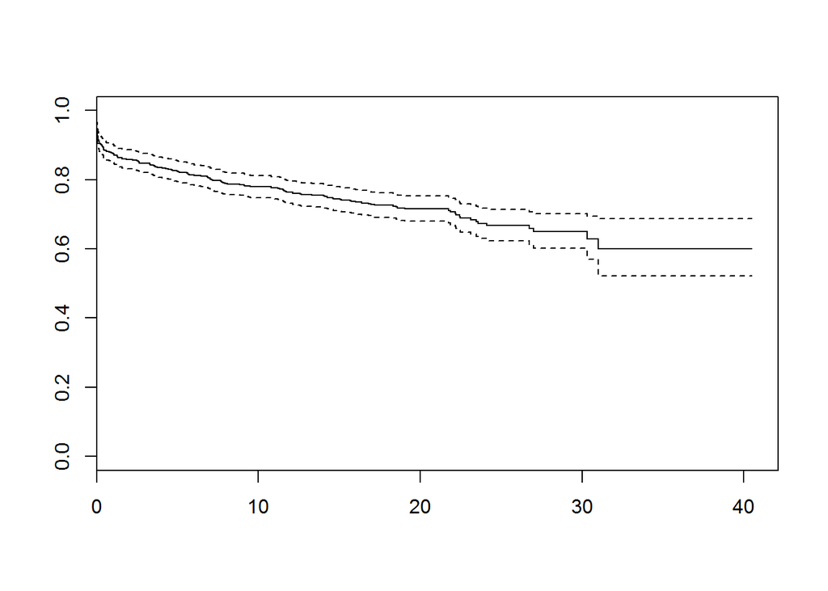

```r
plot(survfit(su~1))
```

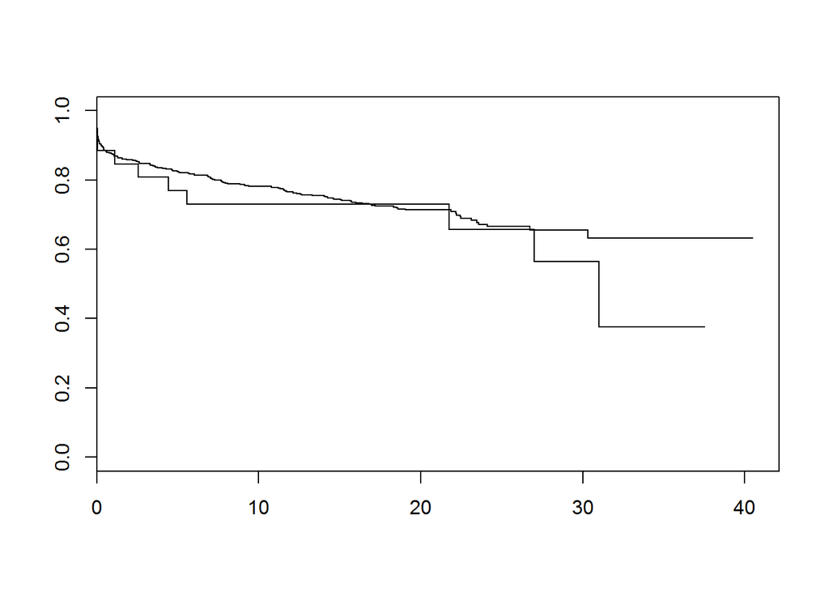

```r
plot(survfit(su~mv1x$mechanical_valve_used_y_n))
```